# 01-methylkit

### Load libraries

```r
list.of.packages <- c("tidyverse", "reshape2", "here", "methylKit", "ggforce", "matrixStats", "Pstat", "viridis", "plotly", "readr", "GenomicRanges", "vegan") #add new libraries here

new.packages <- list.of.packages[!(list.of.packages %in% installed.packages()[,"Package"])]
if(length(new.packages)) install.packages(new.packages)

# Load all libraries
lapply(list.of.packages, FUN = function(X) {
  do.call("require", list(X))
})
```

### Check current directory

```r
getwd()
```

```
## [1] "/Users/laura/Documents/roberts-lab/paper-oly-mbdbs-gen/code"
```

### Download files from `gannet`

### Create list of all bismark data files, which hav reads that are already trimmed and aligned. These BAM files are also sorted and indexed.

### IMPORTANT NOTE: The location of these files depends on where the user saved them. I (Laura) used an external hard drive.

Files were downloaded from gannet on March 9th, 2020 from https://gannet.fish.washington.edu/seashell/bu-mox/scrubbed/020320-oly/ using `curl -O [URL]`:

https://gannet.fish.washington.edu/seashell/bu-mox/scrubbed/020320-oly/zr1394_1_s456_trimmed_bismark_bt2.deduplicated.sorted.bam https://gannet.fish.washington.edu/seashell/bu-mox/scrubbed/020320-oly/zr1394_2_s456_trimmed_bismark_bt2.deduplicated.sorted.bam https://gannet.fish.washington.edu/seashell/bu-mox/scrubbed/020320-oly/zr1394_3_s456_trimmed_bismark_bt2.deduplicated.sorted.bam https://gannet.fish.washington.edu/seashell/bu-mox/scrubbed/020320-oly/zr1394_4_s456_trimmed_bismark_bt2.deduplicated.sorted.bam https://gannet.fish.washington.edu/seashell/bu-mox/scrubbed/020320-oly/zr1394_5_s456_trimmed_bismark_bt2.deduplicated.sorted.bam https://gannet.fish.washington.edu/seashell/bu-mox/scrubbed/020320-oly/zr1394_6_s456_trimmed_bismark_bt2.deduplicated.sorted.bam https://gannet.fish.washington.edu/seashell/bu-mox/scrubbed/020320-oly/zr1394_7_s456_trimmed_bismark_bt2.deduplicated.sorted.bam https://gannet.fish.washington.edu/seashell/bu-mox/scrubbed/020320-oly/zr1394_8_s456_trimmed_bismark_bt2.deduplicated.sorted.bam https://gannet.fish.washington.edu/seashell/bu-mox/scrubbed/020320-oly/zr1394_9_s456_trimmed_bismark_bt2.deduplicated.sorted.bam https://gannet.fish.washington.edu/seashell/bu-mox/scrubbed/020320-oly/zr1394_10_s456_trimmed_bismark_bt2.deduplicated.sorted.bam https://gannet.fish.washington.edu/seashell/bu-mox/scrubbed/020320-oly/zr1394_11_s456_trimmed_bismark_bt2.deduplicated.sorted.bam https://gannet.fish.washington.edu/seashell/bu-mox/scrubbed/020320-oly/zr1394_12_s456_trimmed_bismark_bt2.deduplicated.sorted.bam https://gannet.fish.washington.edu/seashell/bu-mox/scrubbed/020320-oly/zr1394_13_s456_trimmed_bismark_bt2.deduplicated.sorted.bam https://gannet.fish.washington.edu/seashell/bu-mox/scrubbed/020320-oly/zr1394_14_s456_trimmed_bismark_bt2.deduplicated.sorted.bam https://gannet.fish.washington.edu/seashell/bu-mox/scrubbed/020320-oly/zr1394_15_s456_trimmed_bismark_bt2.deduplicated.sorted.bam https://gannet.fish.washington.edu/seashell/bu-mox/scrubbed/020320-oly/zr1394_16_s456_trimmed_bismark_bt2.deduplicated.sorted.bam https://gannet.fish.washington.edu/seashell/bu-mox/scrubbed/020320-oly/zr1394_17_s456_trimmed_bismark_bt2.deduplicated.sorted.bam https://gannet.fish.washington.edu/seashell/bu-mox/scrubbed/020320-oly/zr1394_18_s456_trimmed_bismark_bt2.deduplicated.sorted.bam

```r
file.list_18=list("/Volumes/Peach\ Backup/oly-mbdseq-bismark-files_sorted/zr1394_1_s456_trimmed_bismark_bt2.deduplicated.sorted.bam",
"/Volumes/Peach\ Backup/oly-mbdseq-bismark-files_sorted/zr1394_2_s456_trimmed_bismark_bt2.deduplicated.sorted.bam",
"/Volumes/Peach\ Backup/oly-mbdseq-bismark-files_sorted/zr1394_3_s456_trimmed_bismark_bt2.deduplicated.sorted.bam",
"/Volumes/Peach\ Backup/oly-mbdseq-bismark-files_sorted/zr1394_4_s456_trimmed_bismark_bt2.deduplicated.sorted.bam",
"/Volumes/Peach\ Backup/oly-mbdseq-bismark-files_sorted/zr1394_5_s456_trimmed_bismark_bt2.deduplicated.sorted.bam",
"/Volumes/Peach\ Backup/oly-mbdseq-bismark-files_sorted/zr1394_6_s456_trimmed_bismark_bt2.deduplicated.sorted.bam",
"/Volumes/Peach\ Backup/oly-mbdseq-bismark-files_sorted/zr1394_7_s456_trimmed_bismark_bt2.deduplicated.sorted.bam",
"/Volumes/Peach\ Backup/oly-mbdseq-bismark-files_sorted/zr1394_8_s456_trimmed_bismark_bt2.deduplicated.sorted.bam",
"/Volumes/Peach\ Backup/oly-mbdseq-bismark-files_sorted/zr1394_9_s456_trimmed_bismark_bt2.deduplicated.sorted.bam",
"/Volumes/Peach\ Backup/oly-mbdseq-bismark-files_sorted/zr1394_10_s456_trimmed_bismark_bt2.deduplicated.sorted.bam",
"/Volumes/Peach\ Backup/oly-mbdseq-bismark-files_sorted/zr1394_11_s456_trimmed_bismark_bt2.deduplicated.sorted.bam",
"/Volumes/Peach\ Backup/oly-mbdseq-bismark-files_sorted/zr1394_12_s456_trimmed_bismark_bt2.deduplicated.sorted.bam",
"/Volumes/Peach\ Backup/oly-mbdseq-bismark-files_sorted/zr1394_13_s456_trimmed_bismark_bt2.deduplicated.sorted.bam",
"/Volumes/Peach\ Backup/oly-mbdseq-bismark-files_sorted/zr1394_14_s456_trimmed_bismark_bt2.deduplicated.sorted.bam",
"/Volumes/Peach\ Backup/oly-mbdseq-bismark-files_sorted/zr1394_15_s456_trimmed_bismark_bt2.deduplicated.sorted.bam",
"/Volumes/Peach\ Backup/oly-mbdseq-bismark-files_sorted/zr1394_16_s456_trimmed_bismark_bt2.deduplicated.sorted.bam",
"/Volumes/Peach\ Backup/oly-mbdseq-bismark-files_sorted/zr1394_17_s456_trimmed_bismark_bt2.deduplicated.sorted.bam",
"/Volumes/Peach\ Backup/oly-mbdseq-bismark-files_sorted/zr1394_18_s456_trimmed_bismark_bt2.deduplicated.sorted.bam")
```

### The following command reads sorted BAM files and calls methylation percentage per base, and creates a methylRaw object for CpG methylation.

It also assigns minimum coverage of 2x and the treatments (in this case, the Olympia oyster population)

```r
myobj_18 = processBismarkAln(location = file.list_18, sample.id = list("1","2","3","4","5","6","7","8","9","10","11","12","13","14","15","16","17","18"), assembly = "v071", read.context="CpG", mincov=2, treatment = c(0,0,0,0,0,0,0,0,0,1,1,1,1,1,1,1,1,1))
```

### Save the MethylKit object; re-doing the previous step is memory/time intensive, so best to use the saved object moving forward.

```r
save(myobj_18, file = "../analyses/myobj_18")
```

```bash
#zip ../analyses/myobj_18.zip ../analyses/myobj_18
```

Load object if needed

```r
load("../analyses/myobj_18")
```

### Check the basic stats about the methylation data - coverage and percent methylation. Index the object to look through each sample

```r
getMethylationStats(myobj_18[[2]],plot=F,both.strands=FALSE)
```

```
## methylation statistics per base
## summary:
##    Min. 1st Qu.  Median    Mean 3rd Qu.    Max.
##    0.00   75.00  100.00   84.82  100.00  100.00
## percentiles:
##        0%       10%       20%       30%       40%       50%       60%       70%
##   0.00000  50.00000  66.66667  83.33333 100.00000 100.00000 100.00000 100.00000
##       80%       90%       95%       99%     99.5%     99.9%      100%
## 100.00000 100.00000 100.00000 100.00000 100.00000 100.00000 100.00000
```

```r
head(myobj_18[[5]])
```

```
##       chr start  end strand coverage numCs numTs
## 1 Contig0    37   37      -        2     1     1
## 2 Contig0   483  483      -        3     3     0
## 3 Contig0  1003 1003      +        2     2     0
## 4 Contig0  1036 1036      +        3     1     2
## 5 Contig0   955  955      +        2     2     0
## 6 Contig0  1004 1004      -        2     2     0
```

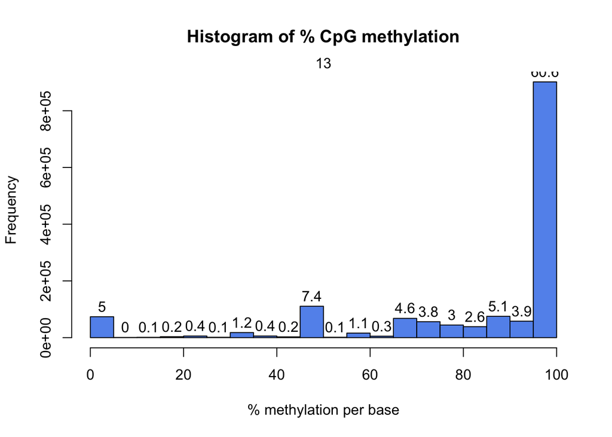

```r
getMethylationStats(myobj_18[[13]],plot=T,both.strands=FALSE)
```

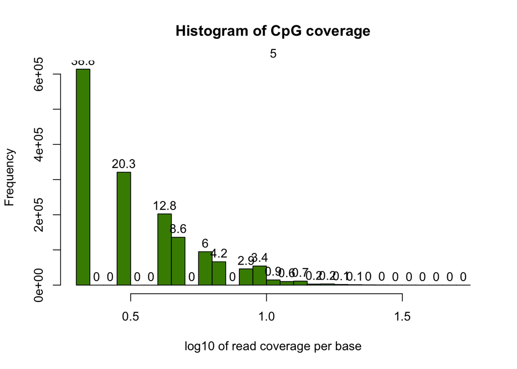

```r
getCoverageStats(myobj_18[[5]],plot=TRUE,both.strands=FALSE)
```

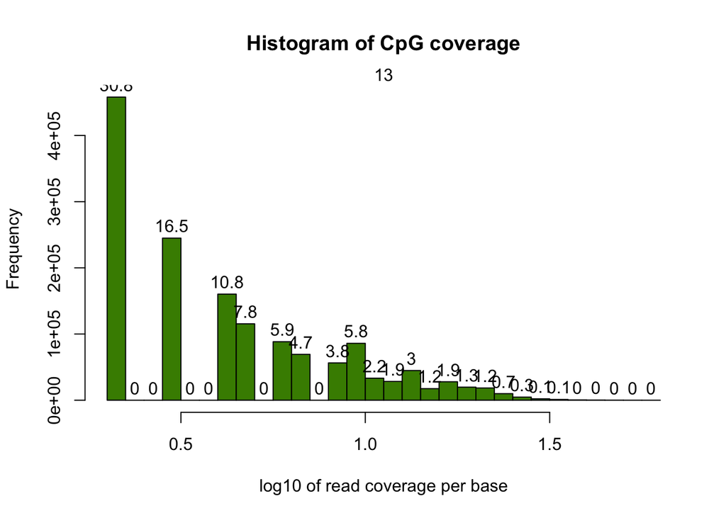

```r
getCoverageStats(myobj_18[[13]],plot=TRUE,both.strands=FALSE)
```

### Filter out loci where coverage is less than 10x or greater than 100x. Then, column bind all samples, keeping only loci that are present in 7 of the 9 samples. Also, destrand.

```r
filtered.myobj=filterByCoverage(myobj_18,lo.count=10,lo.perc=NULL,
                                      hi.count=100,hi.perc=NULL)

meth_filter=methylKit::unite(filtered.myobj, destrand=TRUE, min.per.group=7L)
save(meth_filter, file = "../analyses/methylation-filtered/R-objects/meth_filter") #save object to file
```

Percent methylation matrix (rows=region/base, columns=sample) can be extracted from methylBase object by using percMethylation function. This can be useful for downstream analyses.

Here I create % methylation matrices from the filtered object, and use it to do another cluster analysis

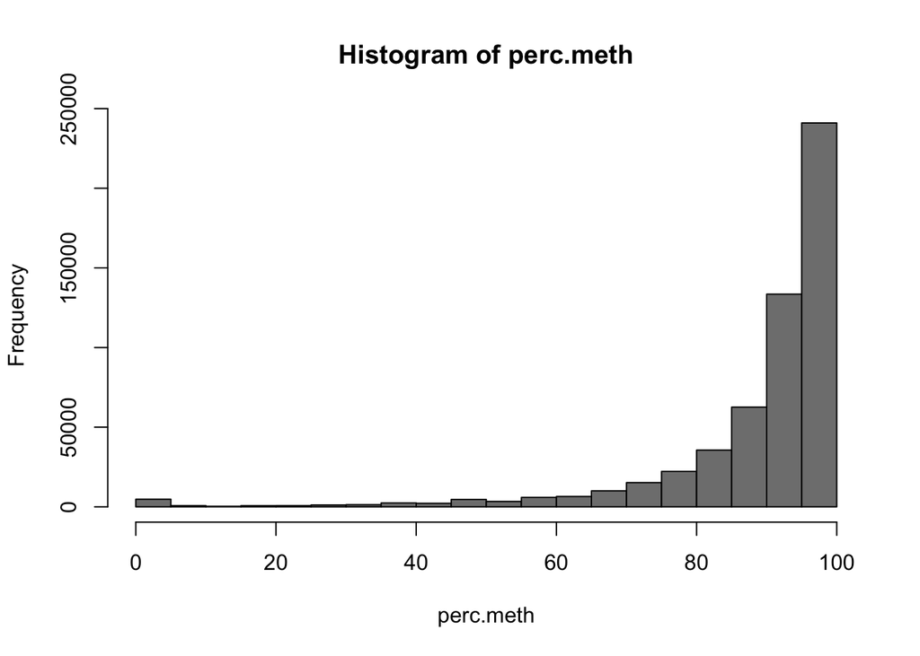

```r
perc.meth=percMethylation(meth_filter, rowids=T)
hist(perc.meth, col="gray50" )
```

```r
# Save % methylation df to object and .tab file
save(perc.meth, file = "../analyses/methylation-filtered/R-objects/perc.meth") #save object to file
write.table((as.data.frame(perc.meth) %>% tibble::rownames_to_column("contig")), file = here::here("analyses", "methylation-filtered", "percent-methylation-filtered.tab"), sep = '\t', na = "NA", row.names = FALSE, col.names = TRUE)

# What percentage of loci have ZERO methylation?
100*table(perc.meth==0)[2]/table(perc.meth==0)[1] # Only 0.8% of loci unmethylated, averaged across all samples
```

```
##      TRUE
## 0.8116747
```

```r
# Mean % methylation across all samples
mean(perc.meth, na.rm=TRUE) # 89.6%
```

```
## [1] 89.5939
```

```r
# Mean % methylation for each populaiton
mean(perc.meth[,1:9], na.rm=TRUE) # 89.6% <-- Hood Canal
```

```
## [1] 89.58982
```

```r
mean(perc.meth[,10:18], na.rm=TRUE) # 89.6%  <-- South Sound
```

```
## [1] 89.59771
```

```r
perc.meth.summ <- data.frame(sample=1:18, methylated=1:18, coverage=1:18, mean.perc=1:18)
for (i in 1:18) {
  perc.meth.summ[i,"sample"] <- i
  perc.meth.summ[i,"methylated"] <-mean(as.vector(getData(meth_filter)[,grep(c("numCs"), colnames(meth_filter))][i][,1]), na.rm=T)
  perc.meth.summ[i,"coverage"] <- mean(as.vector(getData(meth_filter)[,grep(c("coverage"), colnames(meth_filter))][i][,1]), na.rm=T)
  perc.meth.summ[i,"mean.perc"] <- mean(as.vector(getData(meth_filter)[,grep(c("numCs"), colnames(meth_filter))][i][,1]) /
                                     as.vector(getData(meth_filter)[,grep(c("coverage"), colnames(meth_filter))][i][,1]), na.rm=T)
}
mean(perc.meth.summ[1:9,"mean.perc"])
```

```
## [1] 0.8950195
```

```r
mean(perc.meth.summ[10:18,"mean.perc"])
```

```
## [1] 0.8955731
```

```r
myDiff=calculateDiffMeth(meth_filter,mc.cores=4)
```

```
## two groups detected:
##  will calculate methylation difference as the difference of
## treatment (group: 1) - control (group: 0)
```

```r
# get hyper methylated bases
myDiff25p.hyper=getMethylDiff(myDiff,difference=25,qvalue=0.01,type="hyper")
#
# get hypo methylated bases
myDiff25p.hypo=getMethylDiff(myDiff,difference=25,qvalue=0.01,type="hypo")
#
#
# get all differentially methylated bases
myDiff25p=getMethylDiff(myDiff,difference=25,qvalue=0.01)
```

```r
write.table(myDiff25p, file = "../analyses/DMLs/myDiff25p.tab", sep = "\t", col.names = TRUE)
save(myDiff25p, file="../analyses/DMLs/myDiff25p")
```

### Take the DMLs to a bed

```r
# Write out bedfile for DMLs
dml25 <- myDiff25p %>%
  mutate(start = start-1, end = end+1) %>%
  dplyr::select(chr, start, end, meth.diff)
write_delim(dml25, "../analyses/DMLs/dml25.bed",  delim = '\t', col_names = TRUE)
save(dml25, file="../analyses/DMLs/R-objects/dml25")

# Write out bedfile for all loci fed into DML analysis, to use as background for enrichment
mydiff.all <-  mutate(myDiff, start = start -1, end = end + 1) %>% dplyr::select(chr, start, end, meth.diff) %>%
  mutate_if(is.numeric, as.integer)
write_delim(mydiff.all, "../analyses/DMLs/mydiff-all.bed",  delim = '\t', col_names = TRUE)
save(mydiff.all, file="../analyses/DMLs/R-objects/mydiff.all")
```

### This is the number of loci that are differentially methylated among populations (DMLs)

```r
nrow(dml25)
```

```
## [1] 359
```

### Subset the filtered methylation count dataframe for only those that are differentially methylated. Save object to file.

```r
dml25_counts <- selectByOverlap(meth_filter,as(myDiff25p,"GRanges"))
class(dml25_counts) #class should be methylBase
```

```
## [1] "methylBase"
## attr(,"package")
## [1] "methylKit"
```

```r
perc.methDMLs= percMethylation(dml25_counts, rowids=T) #create a percent methylated object for DMLs

# save count and percent objects to be used in subsequent notebook
save(dml25_counts, file = "../analyses/DMLs/R-objects/dml25_counts")
save(perc.methDMLs, file="../analyses/DMLs/R-objects/perc.methDMLs")
```

### Extract correlation matrix (pearson) and distance matrix (manhattan) from the % methylated matrix

FYI I checked that the correlation matrix in `getCorrelation` is derived from the percent methylated matrix. It is!

```r
cor.pears <- cor(perc.meth, method="pearson") # create pearson correlation matrix.
dist.manhat <- dist(t(perc.meth), method = "manhattan", diag = T, upper = F)
dist.manhat.df <- reshape2::melt(as.matrix(dist.manhat), varnames = c("row", "col"))

cor.pears.DMLs <- cor(perc.methDMLs, method="pearson")
dist.manhat.DMLs <- dist(t(perc.methDMLs), method = "manhattan", diag = T, upper = F)
dist.manhat.DMLs.df <- reshape2::melt(as.matrix(dist.manhat.DMLs), varnames = c("row", "col"))
```

### Read in sample number key, merge with distance matrix dataframes

```r
key <- read.csv(here::here("data", "sample-key.csv"))

dist.manhat.df <- merge(x=merge(x=dist.manhat.df, y=key, by.x="row", by.y="MBD.FILENAME"), y=key, by.x="col", by.y="MBD.FILENAME")
colnames(dist.manhat.df) <- c("SeqNum.row", "SeqNum.col", "dist.manh", "SampNum.row", "SampNum.col")
write.csv(dist.manhat.df, file=here::here("analyses", "methylation-filtered", "dist.manhat.csv"), row.names=FALSE)

dist.manhat.DMLs.df <- merge(x=merge(x=dist.manhat.DMLs.df, y=key, by.x="row", by.y="MBD.FILENAME"), y=key, by.x="col", by.y="MBD.FILENAME")
colnames(dist.manhat.DMLs.df) <- c("SeqNum.row", "SeqNum.col", "dist.manh", "SampNum.row", "SampNum.col")
write.csv(dist.manhat.DMLs.df, file=here::here("analyses", "methylation-filtered", "dist.manhat.DMLs.csv"), row.names=FALSE)
```

### Calculate Pst for all methylated loci (using filtered object)

Pst was defined by [Johnson & Kelly, 2019](https://doi.org/10.1111/eva.12912):

I looked through their code, and it’s not totally clear how they did this calculation. BUT I believe they worked with % methylation data at each locus, so I will do the same.

```r
head(perc.meth, 3)
```

```
##                            1        2        3        4        5         6
## Contig0.39226.39226 52.38095 77.27273 45.45455 60.86957 39.13043  61.90476
## Contig0.39234.39234 41.66667 25.92593 37.03704 19.23077 42.85714  44.00000
## Contig0.64179.64179 90.00000 71.42857       NA 94.44444 72.72727 100.00000
##                            7        8        9       10 11       12       13
## Contig0.39226.39226 45.00000 62.50000 58.06452 52.94118 NA 65.21739 58.82353
## Contig0.39234.39234 30.43478 33.33333 22.22222 36.84211 NA 34.48276 42.10526
## Contig0.64179.64179 38.46154 91.66667 61.53846       NA NA 73.68421 72.72727
##                           14   15        16        17       18
## Contig0.39226.39226 50.00000 40.0  61.53846  42.10526 33.33333
## Contig0.39234.39234 41.66667 48.0  29.41176  52.17391 31.25000
## Contig0.64179.64179 76.19048 87.5 100.00000 100.00000 46.66667
```

The following R code was provided by Kevin Johnson

```r
perc.meth.Pst <- read_delim(file = here::here("analyses",  "methylation-filtered", "percent-methylation-filtered.tab"), delim = "\t", col_names = TRUE)
apply(perc.meth.Pst, 2, function(x) any(is.na(x))) #any NA values?
```

```
## contig      1      2      3      4      5      6      7      8      9     10
##  FALSE   TRUE   TRUE   TRUE   TRUE   TRUE   TRUE   TRUE   TRUE   TRUE   TRUE
##     11     12     13     14     15     16     17     18
##   TRUE   TRUE   TRUE   TRUE   TRUE   TRUE   TRUE   TRUE
```

```r
#Here I removed rows with NA values, the Pstat function will work with some NA values, but to speed things up I removed them
perc.meth.Pst2 <- perc.meth.Pst[c(complete.cases(perc.meth.Pst)),]
apply(perc.meth.Pst2, 2, function(x) any(is.na(x))) #confirm no more NA values
```

```
## contig      1      2      3      4      5      6      7      8      9     10
##  FALSE  FALSE  FALSE  FALSE  FALSE  FALSE  FALSE  FALSE  FALSE  FALSE  FALSE
##     11     12     13     14     15     16     17     18
##  FALSE  FALSE  FALSE  FALSE  FALSE  FALSE  FALSE  FALSE
```

```r
#I also removed rows that had a mean methylation value of 0 as these throw off the calculation
perc.meth.Pst2 <- perc.meth.Pst2[c(rowMeans(perc.meth.Pst2[-1] )>0),]

#If you want to see how this influences the Pst.hc vs Pst.ss comparison run the next line:
#perc.meth.Pst <- perc.meth.Pst2

#Now I modify the data a little bit, first setting contig as row name
#perc.meth.Pst2 <- as.data.frame(perc.meth.Pst)
row.names(perc.meth.Pst2) <- perc.meth.Pst2$contig
perc.meth.Pst2$contig = NULL

#Now I flip the data frame so that each column is a unique loci
perc.meth.Pst2 <- as.data.frame(t(perc.meth.Pst2))

#Now add a new column that has population assignment
perc.meth.Pst2$Population <- c("HC","HC","HC","HC","HC","HC","HC","HC","HC","SS","SS","SS","SS","SS","SS","SS","SS","SS")
ncol(perc.meth.Pst2)
```

```
## [1] 7826
```

```r
#reorder these columns so that population is the first column
perc.meth.Pst2 <- perc.meth.Pst2[,c(7826,1:7825)]

require(Pstat)

#Now run the following line and it will provide Pst estimates for every gene. NOTE: this can take a long time.
perc.meth.Pst.done <- Pst(perc.meth.Pst2)
```

```
## [1] "Populations sizes are:"
## HC SS
##  9  9
```

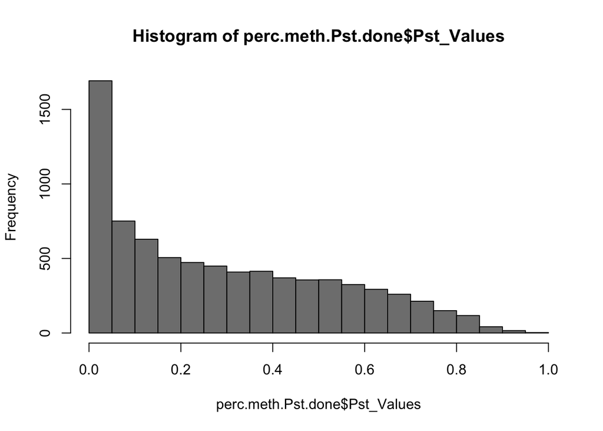

```r
save(perc.meth.Pst.done, file="../analyses/methylation-filtered/R-objects/perc.meth.Pst.done")

# Load Pst dataframe if needed.
#load("../analyses/methylation-filtered/R-objects/perc.meth.Pst.done")
hist(perc.meth.Pst.done$Pst_Values, col = "gray50")
```

```r
summary(perc.meth.Pst.done$Pst_Values)
```

```
##    Min. 1st Qu.  Median    Mean 3rd Qu.    Max.
## 0.00000 0.06509 0.23269 0.28724 0.47375 0.95411
```

```r
nrow(perc.meth.Pst.done)
```

```
## [1] 7825
```

```r
# Write out Pst results
write.table(perc.meth.Pst.done, file = here::here("analyses", "methylation-filtered", "Pst_locus.tab"), sep = '\t', na = "NA", row.names = FALSE, col.names = FALSE)
```